# Project Python Foundations: FoodHub Data Analysis

#### Categorical columns

##### 1. Cuisine Type

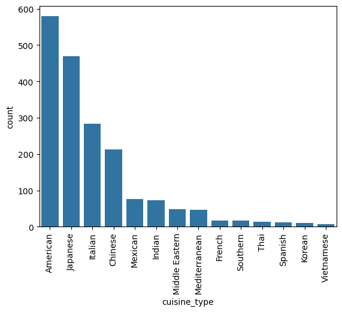

```python
# Creates a descending order for cuisine type
order_descending = df_treated['cuisine_type'].value_counts().index

# Plots a countplot of the feature cuisine type
sns.countplot(data=df_treated, x='cuisine_type', order=order_descending)
plt.xticks(rotation=90)
plt.show()
```

- The majority of orders come from American, Japanese, Italian and Chinese cuisines.
- There is lower demand for Middle Eastern, Mediterranean, Thai, French, Southern, Korean, Spanish and Vietnamise cuisines.

##### 2. Day of the week

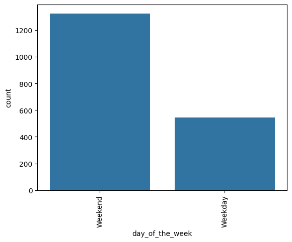

```python
# Plots a countplot of the feature day of the week

sns.countplot(data=df_treated, x='day_of_the_week')
plt.xticks(rotation=90)
plt.show()
```

- There is a higher demand on Weekends than on Weekdays.

##### 3. Restaurant name

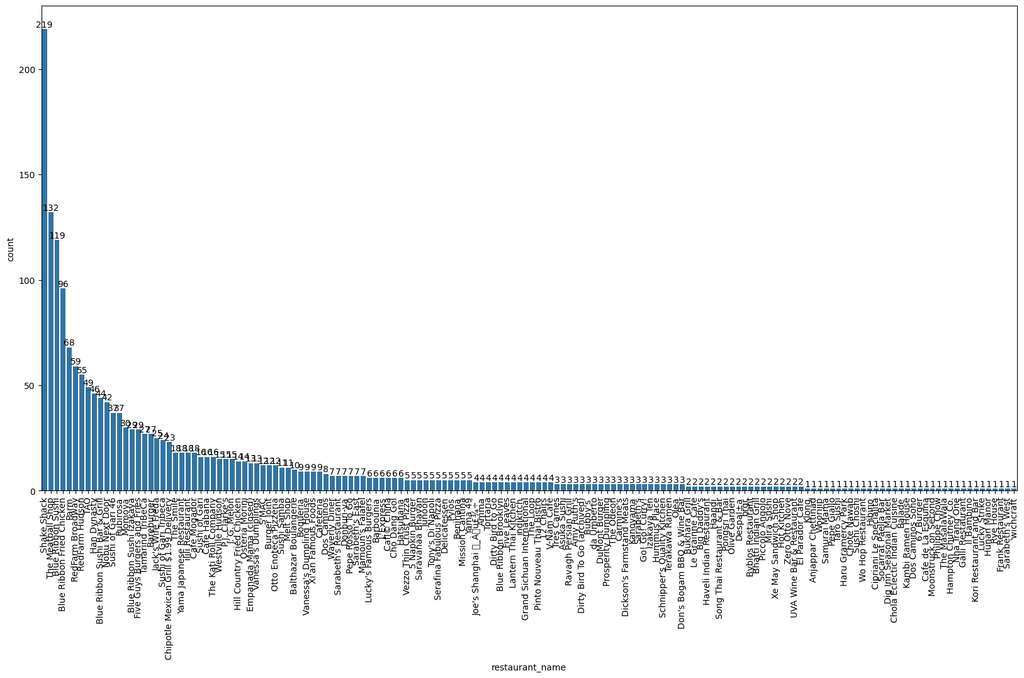

```python
# Creates a dataset with the top five restaurants in terms of orders
plt.figure(figsize=(20, 10))

ax = sns.barplot(data=df_treated['restaurant_name'].value_counts().reset_index(), x='restaurant_name', y='count')

# Plots a bar plot of those restaurants
for container in ax.containers:
    ax.bar_label(container)
plt.xticks(rotation=90)
plt.show()
```

- There is a right skewed distribution of restaurants.
- The seems to be a concentration of orders in a few restaurants.

##### 4. Order id

```python
# Check for duplicates in the order_id column
df_duplicates = df_treated[df_treated.groupby('order_id')['order_id'].transform('count') > 1]
df_duplicates.head()
```

|  | order_id | customer_id | restaurant_name | cuisine_type | cost_of_the_order | day_of_the_week | rating | food_preparation_time | delivery_time |
| --- | --- | --- | --- | --- | --- | --- | --- | --- | --- |

Since order_id is a unique key, there is no need for a univariate analysis. So, the code above has the goal to make sure there is no duplicates on order_id and there is not.

##### 5. Customer id

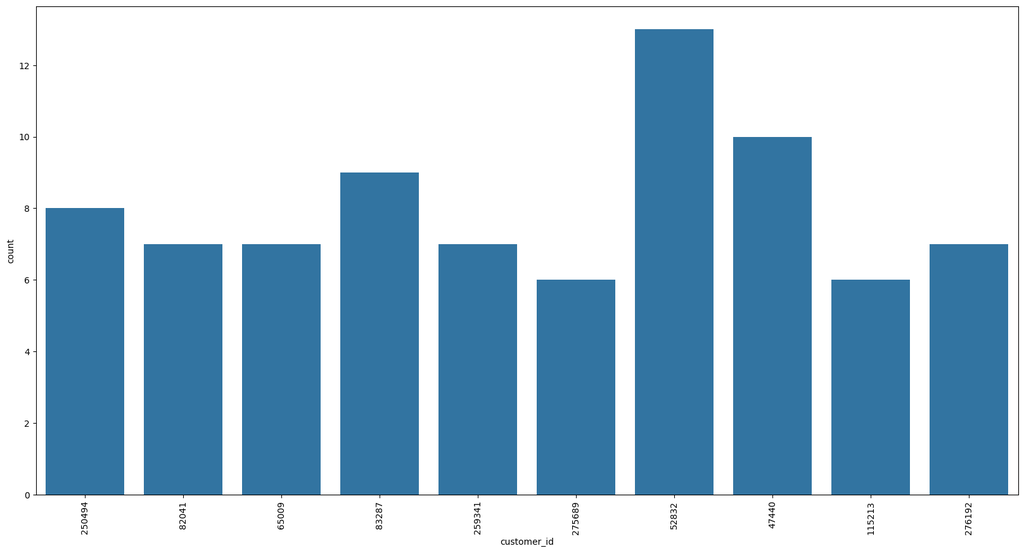

```python
# Creates a list of the top 10 most frequent customers
most_frequent_customers = df_treated.sort_values('customer_id').groupby(['customer_id']).agg({'order_id':'count'}).sort_values(by='order_id',ascending=False).nlargest(10, columns='order_id').reset_index()['customer_id'].to_list()
# Creates a boolean with indicantes if those frequent customers are present in rows
df_most_frequent_customers = df_treated['customer_id'].isin(most_frequent_customers)

# Filters only the rows with most frequent customers
df_most_frequent_clients = df_treated[df_most_frequent_customers]

plt.figure(figsize=(20, 10))

# Plots a countplot based on customer_id
sns.countplot(data=df_most_frequent_clients, x='customer_id')
plt.xticks(rotation=90)
plt.show()
```

Since there are many customers in the dataset, the plot counts the entries of the most frequent customers.

- Even in most frequent customers, the average number of orders is less than 10 orders.

##### 6. Rating

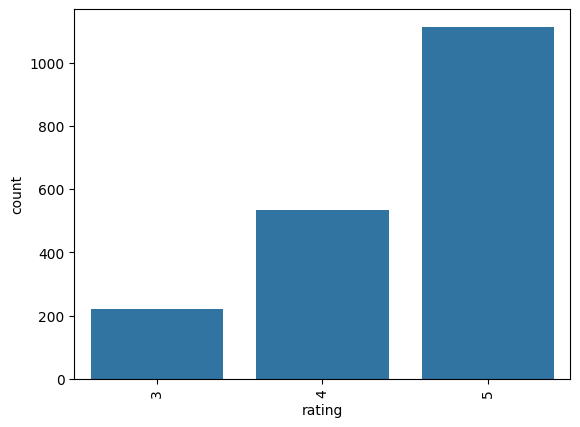

```python
# Creates a descending order for cuisine type
order_ascending = df_treated['rating'].value_counts(ascending=True).index

# Plots a countplot of the feature cuisine type
sns.countplot(data=df_treated, x='rating', order=order_ascending)
plt.xticks(rotation=90)
plt.show()
```

- Most ratings are concentrated on 4 or 5.

### **Question 7**: Which are the top 5 restaurants in terms of the number of orders received? [1 mark]

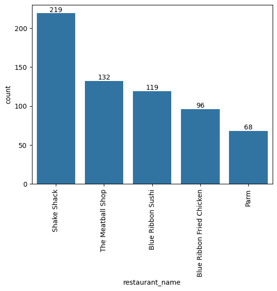

```python
# Creates a dataset with the top five restaurants in terms of orders
ax = sns.barplot(data=df_treated['restaurant_name'].value_counts().nlargest(5).reset_index(), x='restaurant_name', y='count')

# Plots a bar plot of those restaurants
for container in ax.containers:
    ax.bar_label(container)
plt.xticks(rotation=90)
plt.show()
```

#### Observations:

The top 5 restaurants in terms of orders are:

- Shake Shack (219 orders)
- The Meetball Shop (132 orders)
- Blue Ribbon Sushi (119 orders)
- Blue Ribbon Fried Chicken (96 orders)
- Parm (68 orders)

### **Question 8**: Which is the most popular cuisine on weekends? [1 mark]

```python
# Filters entries on weekends, finds the number of entries per cuisine type and filters the five largest numbers

df[df['day_of_the_week'] == 'Weekend']['cuisine_type'].value_counts(ascending=False).nlargest(5)
```

| cuisine_type | count |
| --- | --- |
| American | 415 |
| Japanese | 335 |
| Italian | 207 |
| Chinese | 163 |
| Mexican | 53 |

**dtype:** int64

#### Observations:

The most popular cuisine on weekends is American with 415 orders.

### **Question 9**: What percentage of the orders cost more than 20 dollars? [2 marks]

```python
# Divides the number of entries with cost bigger than 20 dollars by the total number of entries in the dataset

(df_treated[df_treated['cost_of_the_order'] > 20]['cost_of_the_order'].count()/df_treated['cost_of_the_order'].count() * 100)
```

```
np.float64(29.17558886509636)
```

#### Observations:

29.2% of orders cost more than 20 dollars.

### **Question 10**: What is the mean order delivery time? [1 mark]

```python
# Gets the mean of delivery_time column

df_treated['delivery_time'].mean()
```

```
np.float64(24.18522483940043)
```

#### Observations:

Delivery time mean orders is 24 minutes.

### **Question 11:** The company has decided to give 20% discount vouchers to the top 3 most frequent customers. Find the IDs of these customers and the number of orders they placed. [1 mark]

```python
# Gets the number of orders per customer and filter the three highest values

df_treated['customer_id'].value_counts().nlargest(3)
```

| customer_id | count |
| --- | --- |
| 52832 | 13 |
| 47440 | 10 |
| 83287 | 9 |

**dtype:** int64

#### Observations:

The customers receiving the 20% discount are: 52832 (13 orders), 47440 (10 orders) and 83287 (9 orders).

### **Question 12**: Perform a multivariate analysis to explore relationships between the important variables in the dataset. (It is a good idea to explore relations between numerical variables as well as relations between numerical and categorical variables) [10 marks]

#### Numerical columns relationship

```python
# Transforms the column rating in numerical of type float
df_treated['rating'] = df_treated['rating'].astype('float')
```

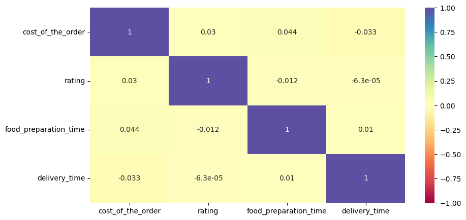

```python
plt.figure(figsize=(10,5))
sns.heatmap(df_treated.select_dtypes(include=np.number).corr(),annot=True,cmap='Spectral',vmin=-1,vmax=1)
plt.show()
```

The Rating column is transformed in numerical to identify its correlation with the other columns.

The correlations vary between -0.03 and 0.04, so there are no strong correlation between the variables.

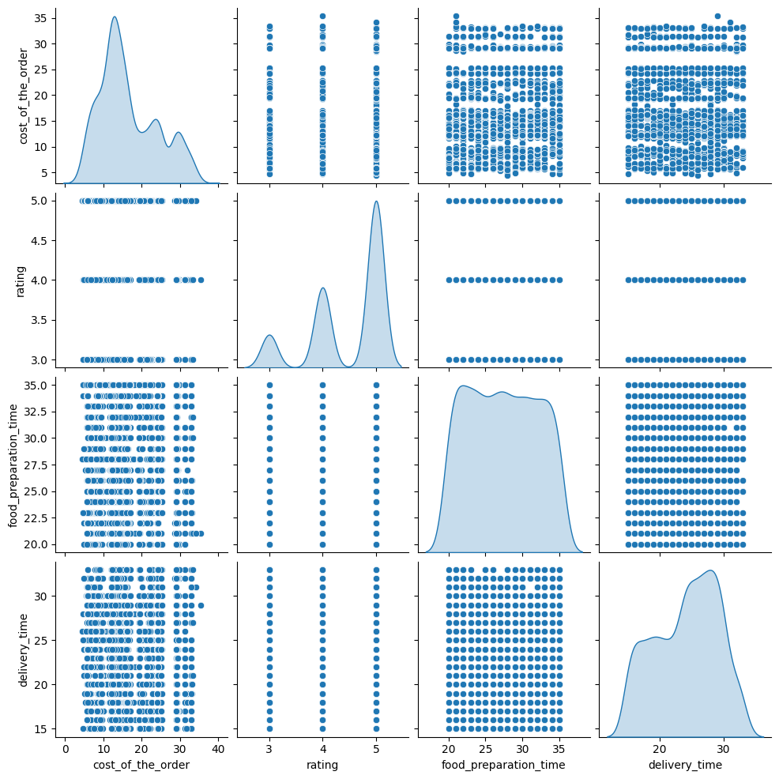

```python
sns.pairplot(data=df_treated.select_dtypes(include=np.number), diag_kind="kde")
plt.show()
```

The pairplot shows the relationship between every two numerical features on the dataset. It is possible to support the findings above, as there is not strong correlation between any variables.

#### Exploring the relationship between rating and other features

This section will focus on ratings, since the goal of the analysis is to improve customer experience.

```python
# To improve the analysis from now on, we calculated the total time feature, which consists in the sum of food preparation time and delivery time
df_treated['total_time'] = df_treated['food_preparation_time'] + df_treated['delivery_time']
```

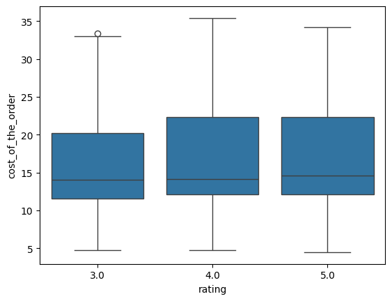

```python
# Plots a boxplot with rating in the x axis and cost of the order in the y axis
sns.boxplot(data=df_treated,x='rating',y='cost_of_the_order')
plt.show()
```

- There does not seem to be a strong relationship between the cost of the order and the rating the order received.
- There is just one outlier in the cost of rating 3

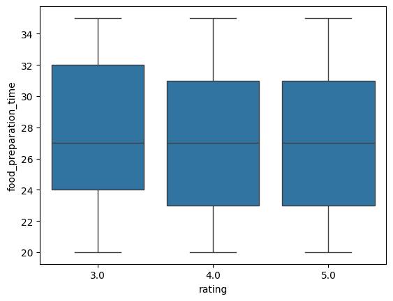

```python
# Plots a boxplot with rating in the x axis and food preparation time in the y axis

sns.boxplot(data=df_treated,x='rating',y='food_preparation_time')
plt.show()
```

- There does not seem to be a strong relationship between the food preparation time and the rating the order received.

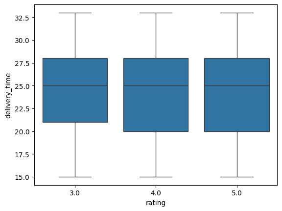

```python
# Plots a boxplot with rating in the x axis and delivery time in the y axis

sns.boxplot(data=df_treated,x='rating',y='delivery_time')
plt.show()
```

- There does not seem to be a strong relationship between the delivery time and the rating the order received

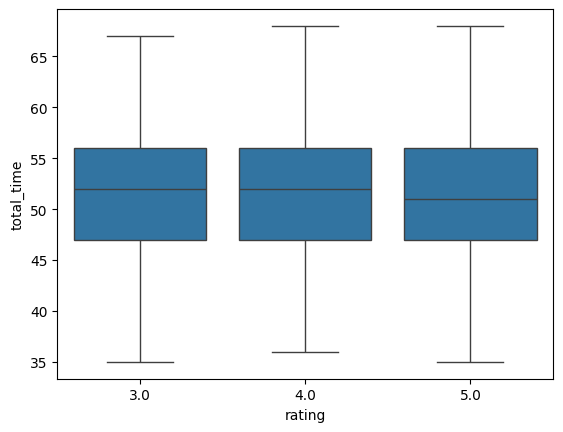

```python
# Plots a boxplot with rating in the x axis and total time in the y axis

sns.boxplot(data=df_treated,x='rating',y='total_time')
plt.show()
```

- There does not seem to be a strong relationship between the total time of the orders and its rating

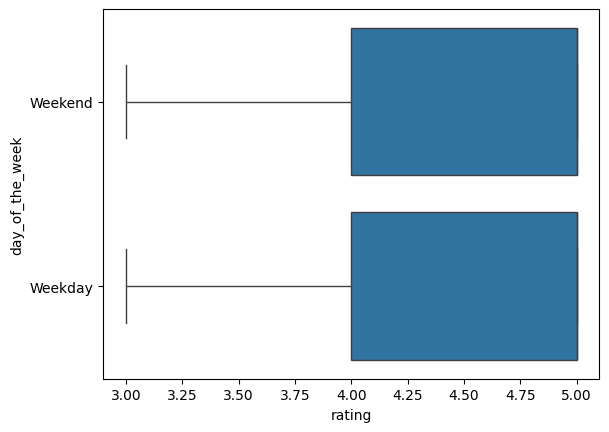

```python
# Plots a boxplot with rating in the x axis and day of the week in the y axis

sns.boxplot(data=df_treated,x='rating',y='day_of_the_week')
plt.show()
```

- There does not seem to be a strong relationship relationship between day of the week and the rating the order received.

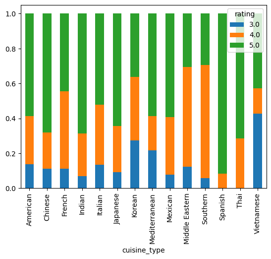

```python
# Divides the number of different raitings per cuisine type by the number of different rating in the dataset. Then it creates a stacked bar plot with the percentages of rating per cuisine type.

(df_treated.groupby(['cuisine_type','rating'])['rating'].count()/df_treated.groupby(['cuisine_type'])['rating'].count()).unstack().plot.bar(stacked=True)
```

- The plot above shows that the percentage of raitings can vary between different types of cuisine. However, some of those cuisine types have a small number of orders, which can mislead the analysis. So, the relationship between different types of cuisine and rating will be explored below with the most frequent types of cuisine.

```python
# Gets a list of the 6 most frequent cuisine types in the dataset. The cut has been made regarding cuisine types that have at least 50 orders
most_frequent_cuisines = df_treated.sort_values('cuisine_type').groupby(['cuisine_type']).agg({'order_id':'count'}).sort_values(by='order_id',ascending=False).nlargest(6, columns='order_id').reset_index()['cuisine_type'].to_list()

# Created a boolean which indicates if the cuisine type in the row is one of the most frequent cuisine types
df_cuisine_type = df_treated['cuisine_type'].isin(most_frequent_cuisines)

# Filters rows from the most frequent cuisine types
df_cuisine_type = df_treated[df_cuisine_type]
```

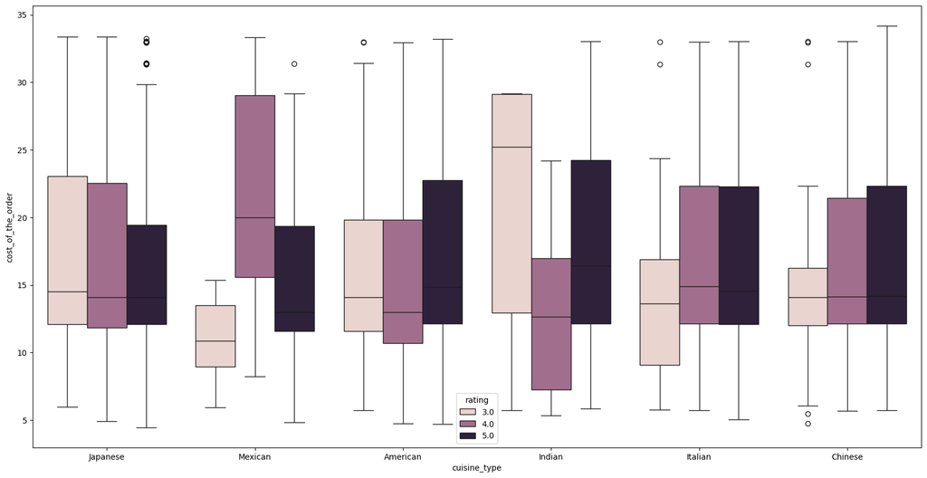

```python
# Plots a boxplot with cuisine type in the x axis, cost of the order in the y axis divided by rating
plt.figure(figsize=(20, 10))
sns.boxplot(data=df_cuisine_type,x='cuisine_type',y='cost_of_the_order', hue='rating')
plt.show()
```

- There seems to exist a tendency between low cost and low rating in Mexican, Chinese and Italian cuisine types.
- There seems to exist a tendency between high cost and low rating in Indian cuisine type.
- A correlation matrix will be plotted for each one of these cuisine types to understand if there is a relevant correlation.

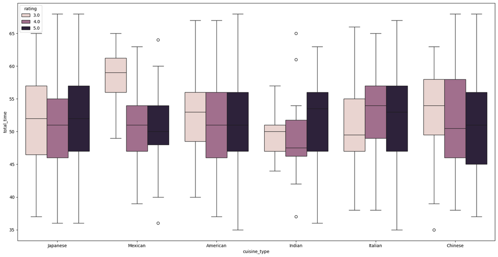

```python
# Plots a boxplot with cuisine type in the x axis, cost of the order in the y axis divided by rating
plt.figure(figsize=(20, 10))
sns.boxplot(data=df_cuisine_type,x='cuisine_type',y='total_time', hue='rating')
plt.show()
```

- There seems to exist a tendency between higher total time cost and low rating in Mexican cuisine type.
- A correlation matrix will be plotted for each one of these cuisine types to understand if there is a relevant correlation.

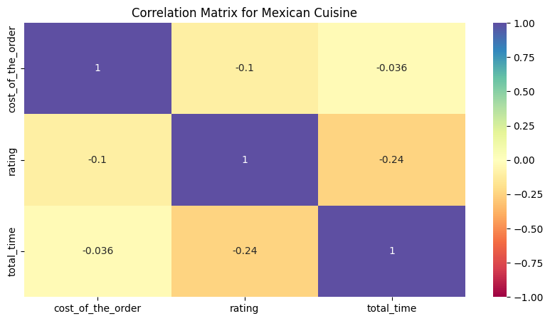

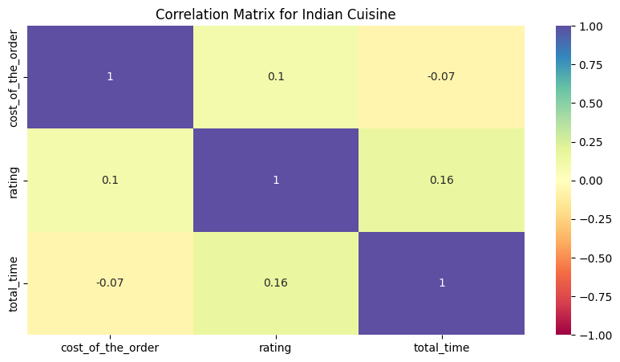

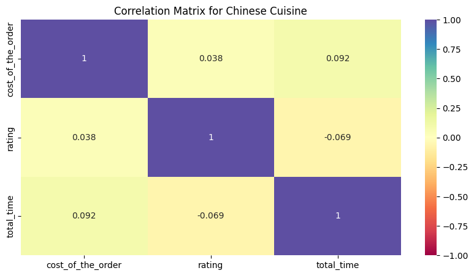

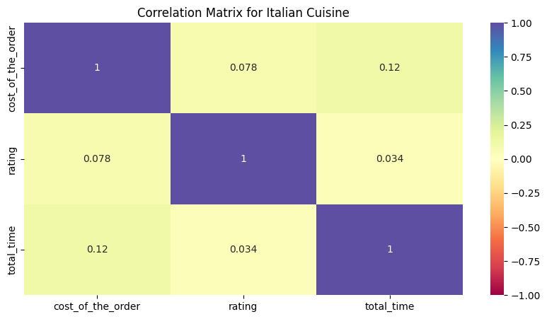

```python
# Plots a linear correlation matrix for each one of the cuisine types in the list

cuisine_type_list = ['Mexican', 'Indian', 'Chinese', 'Italian']

for cuisine in cuisine_type_list:
  selected_cuisine_type = df_treated[df_treated['cuisine_type'] == cuisine]
  plt.figure(figsize=(10,5))
  sns.heatmap(selected_cuisine_type.loc[:, ['cost_of_the_order', 'rating', 'total_time']].corr(),annot=True,cmap='Spectral',vmin=-1,vmax=1)
  plt.title(f'Correlation Matrix for {cuisine} Cuisine')
  plt.show()
```

- The correlation matrix for the cuisine types do not show a linear correlation between cost of the order and rating. So, we will try to perform a non linear correlation.
- The correlation matrix for the cuisine types show a medium negative linear correlation (-0.24) between total time and rating in Mexican cuisine. Which means orders which take the longest to get delivered tend to have worse ratings.
- The contrary seems to be true for Indian cuisine. Although the correlation is weak, there is a 0.16 positive correlation between total time of preparation and delivery of an order and the rating the order receives.

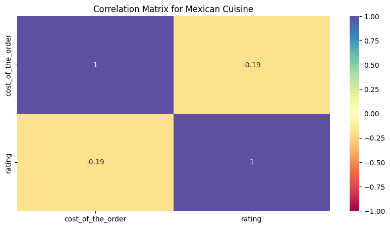

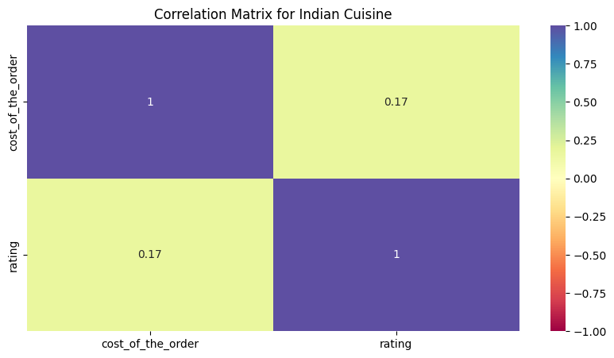

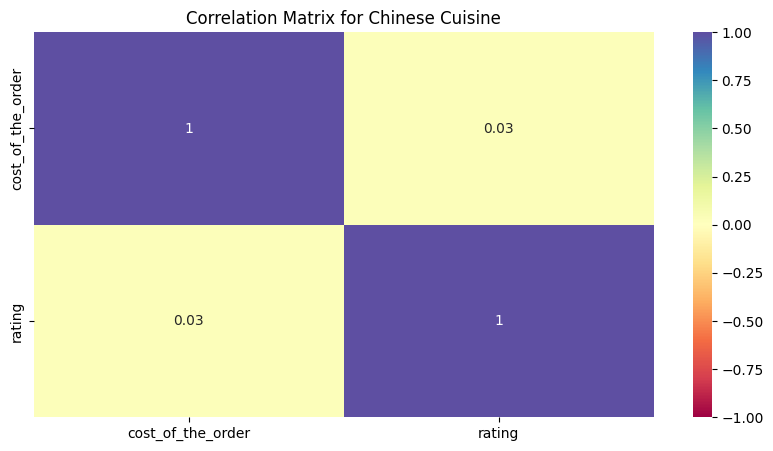

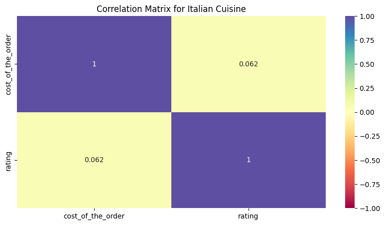

```python
# Plots a non linear correlation matrix (with Spearman method) for each one of the cuisine types in the list

cuisine_type_list = ['Mexican', 'Indian', 'Chinese', 'Italian']

for cuisine in cuisine_type_list:
  selected_cuisine_type = df_treated[df_treated['cuisine_type'] == cuisine]
  plt.figure(figsize=(10,5))
  sns.heatmap(selected_cuisine_type.loc[:, ['cost_of_the_order', 'rating']].corr(method='spearman'),annot=True,cmap='Spectral',vmin=-1,vmax=1)
  plt.title(f'Correlation Matrix for {cuisine} Cuisine')
  plt.show()
```

- The correlation matrix for the cuisine types show a negative non linear correlation (-0.19) between cost of the order and rating in Mexican cuisine. Which means orders which have the higher prices tend to have worse ratings.
- The contrary seems to be true for Indian cuisine. Although the correlation is not strong, there is a 0.17 positive correlation between cost of the order and the rating the order receives.
- The rest of the cuisines analyzed don't show any relevant non linear correlations.

Final observations:

- There is not a strong relationship between general ratings and cost of the order, total time of delivery and day of the week.
- However, there is relevant relationship between cost of the order and rating and total time of delivery and rating in Indian and Mexican cuisines.
- Although the correlations are not strong, orders with higher prices and higher total time of delivery tend to have worse ratings in Mexican Cuisine.
- Although the correlations are not strong and it is contrary to intuition, orders with higher prices and higher total time of delivery tend to have better ratings in Indian Cuisine.